# IODS course project

# Student performance (incl. alcohol consumption)

This is an exercise on data from two questionnaires related to student performance (especially including alcohol consumption). More information about the data sets can be found in the link below.

https://archive.ics.uci.edu/ml/datasets/Student+Performance

The data have been adjusted as follow :  
* The variables not used for joining the two data have been combined by averaging (including the grade variables)  
* ‘alc_use’ is the average of ‘Dalc’ and ‘Walc’  
* ‘high_use’ is TRUE if ‘alc_use’ is higher than 2 and FALSE otherwise

```r
#Read the analysis dataset from data folder
alc <- read.csv("http://s3.amazonaws.com/assets.datacamp.com/production/course_2218/datasets/alc.txt", header = TRUE, sep =",")
colnames(alc)
```

```
##  [1] "school"     "sex"        "age"        "address"    "famsize"
##  [6] "Pstatus"    "Medu"       "Fedu"       "Mjob"       "Fjob"
## [11] "reason"     "nursery"    "internet"   "guardian"   "traveltime"
## [16] "studytime"  "failures"   "schoolsup"  "famsup"     "paid"
## [21] "activities" "higher"     "romantic"   "famrel"     "freetime"
## [26] "goout"      "Dalc"       "Walc"       "health"     "absences"
## [31] "G1"         "G2"         "G3"         "alc_use"    "high_use"
```

The purpose of the analysis is to study the relationships between high/low alcohol consumption and some of the other variables in the data. To do this, 4 interesting variables have been chosen. The hypothesis for the chosen variables and about their relationships with alcohol consumption are as follows: Variables 1-4 (listed below) with values hig, A, high and no will increase alcohol consumption

1.goout - going out with friends (numeric: from 1 - very low to 5 - very high):high  
2.Pstatus - parent’s cohabitation status (binary: ‘T’ - living together or ‘A’ - apart):A  
3.freetime - free time after school (numeric: from 1 - very low to 5 - very high):high  
4.activities - extra-curricular activities (binary: yes or no):no

The distribution of chosen variables and relationships with alcohol consumption is explored with cross-tabulations, bar plot and box plots.

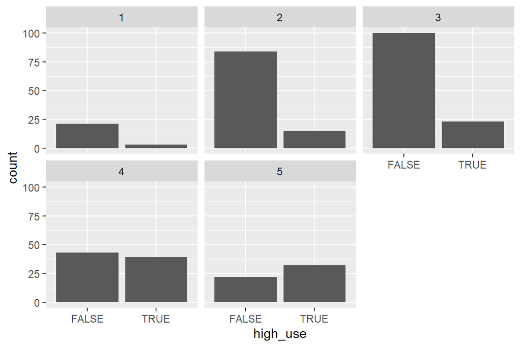

```r
# access the dplyr library and gglot2
library(dplyr); library(ggplot2)
#check for chosen variables
#alc_own <- select(alc, "goout","Pstatus","freetime","activities")
#alc_own

# access the 'tidyverse' packages dplyr and ggplot2
library(dplyr); library(ggplot2)

# initialize a plot of alcohol use
g1 <- ggplot(data = alc, aes(x = alc_use, fill = goout))

# define the plot as a bar plot and draw it
#g1 + geom_bar()

# initialize a plot of 'high_use'
g2 <- ggplot(alc, aes(high_use))

# draw a bar plot of high_use by sex
g2 + facet_wrap("goout") + geom_bar()
```

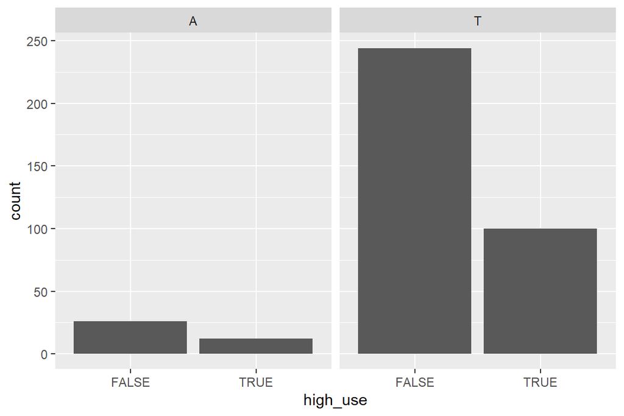

```r
g2 + facet_wrap("Pstatus") + geom_bar()
```

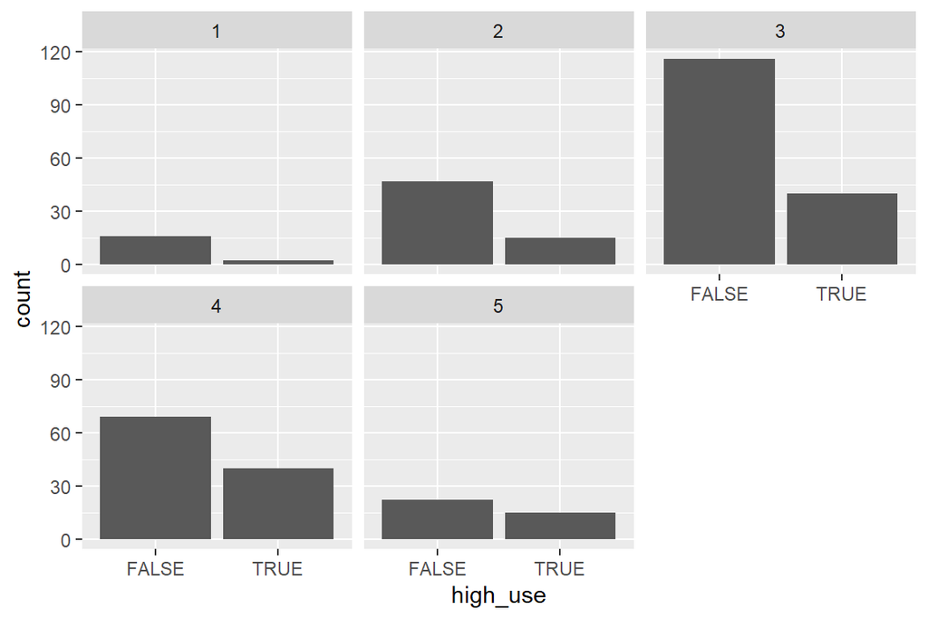

```r
g2 + facet_wrap("freetime") + geom_bar()
```

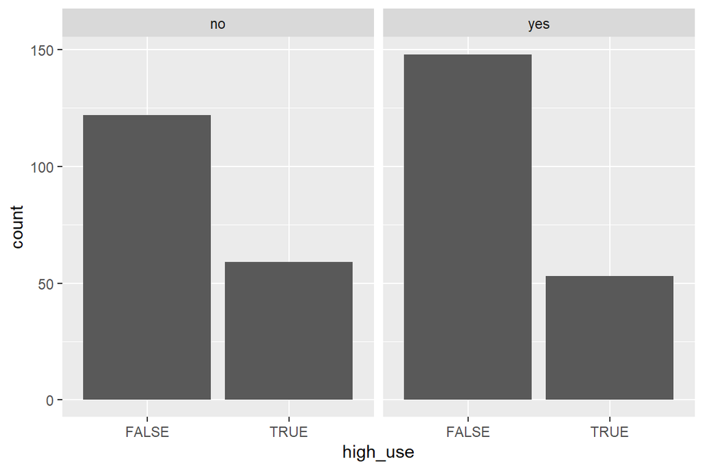

```r
g2 + facet_wrap("activities") + geom_bar()
```

```r
# produce summary statistics by group
alc %>% group_by(goout, high_use) %>% summarise(count = n(), mean_grade = mean(G3))
```

```
## # A tibble: 10 x 4
## # Groups:   goout [5]
##    goout high_use count mean_grade
##    <int> <lgl>    <int>      <dbl>
##  1     1 FALSE       21       9.19
##  2     1 TRUE         3      10.3
##  3     2 FALSE       84      11.1
##  4     2 TRUE        15      11.3
##  5     3 FALSE      100      11.2
##  6     3 TRUE        23      10.3
##  7     4 FALSE       43       9.93
##  8     4 TRUE        39       9.90
##  9     5 FALSE       22       7.59
## 10     5 TRUE        32       9.75
```

```r
alc %>% group_by(Pstatus, high_use) %>% summarise(count = n(), mean_grade = mean(G3))
```

```
## # A tibble: 4 x 4
## # Groups:   Pstatus [2]
##   Pstatus high_use count mean_grade
##   <chr>   <lgl>    <int>      <dbl>
## 1 A       FALSE       26       11.3
## 2 A       TRUE        12       10.9
## 3 T       FALSE      244       10.4
## 4 T       TRUE       100       10.0
```

```r
alc %>% group_by(freetime, high_use) %>% summarise(count = n(), mean_grade = mean(G3))
```

```
## # A tibble: 10 x 4
## # Groups:   freetime [5]
##    freetime high_use count mean_grade
##       <int> <lgl>    <int>      <dbl>
##  1        1 FALSE       16       9.12
##  2        1 TRUE         2       8.5
##  3        2 FALSE       47      11.9
##  4        2 TRUE        15      11.6
##  5        3 FALSE      116       9.75
##  6        3 TRUE        40       9.82
##  7        4 FALSE       69      10.5
##  8        4 TRUE        40      10.1
##  9        5 FALSE       22      12.5
## 10        5 TRUE        15       9.8
```

```r
alc %>% group_by(activities, high_use) %>% summarise(count = n(), mean_grade = mean(G3))
```

```
## # A tibble: 4 x 4
## # Groups:   activities [2]
##   activities high_use count mean_grade
##   <chr>      <lgl>    <int>      <dbl>
## 1 no         FALSE      122       10.2
## 2 no         TRUE        59       10.1
## 3 yes        FALSE      148       10.7
## 4 yes        TRUE        53       10.2
```

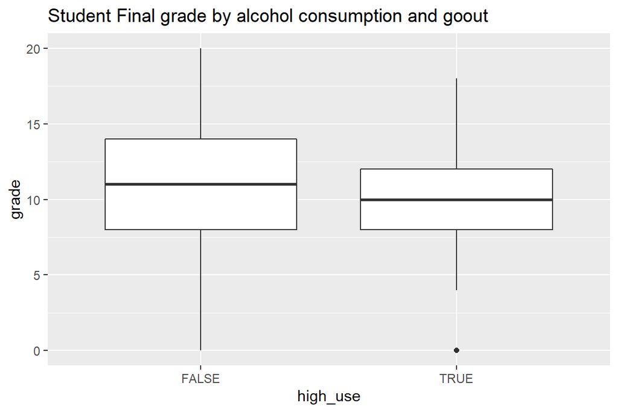

```r
#box plots
#go out
# initialize a plot of high_use and G3
g1 <- ggplot(alc, aes(x = high_use, y = G3, col = goout))

# define the plot as a boxplot and draw it
g1 + geom_boxplot() + ylab("grade") + ggtitle("Student Final grade by alcohol consumption and goout")
```